# Assignment (Joins/SAC)

Abhijit Dasgupta

October 24, 2018

The World Health Organization provides detailed data on various population health indicators in an Open Data environment. The R package `WHO` allows you to access that data directly from R. Install this package using `install.packages('WHO')`.

> The package has a nice vignette, which can be accessed using `library(WHO); vignette('who_vignette')`

We will be using this package to download data on infant and under-5 mortality and exploring the merging of data sets and the split-apply-combine paradigm

You can download these data sets using the following code:

```r
library(WHO)
infant <- get_data('EQ_INFANTMORT')
child <- get_data('EQ_U5MORT')
```

## Merging

1. Understand the structure of each data set using `str`, and find common variables

```r
str(infant)
```

```
## Classes 'tbl_df', 'tbl' and 'data.frame':    1978 obs. of  9 variables:
##  $ publishstate     : chr  "Published" "Published" "Published" "Published" ...
##  $ datasource       : chr  "MICS" "MICS" "MICS" "MICS" ...
##  $ country          : chr  "Afghanistan" "Afghanistan" "Afghanistan" "Afghanistan" ...
##  $ region           : chr  "Eastern Mediterranean" "Eastern Mediterranean" "Eastern Mediterranean" "Eastern Mediterranean" ...
##  $ year             : num  2010 2010 2010 2010 2010 ...
##  $ gho              : chr  "Infant mortality per 1 000 live births" "Infant mortality per 1 000 live births" "Infant mortality per 1 000 live births" "Infant mortality per 1 000 live births" ...
##  $ value            : num  65.9 56.6 67.6 63.5 50.4 59.9 53.1 53.1 16.7 17 ...
##  $ residenceareatype: chr  NA "Urban" "Rural" NA ...
##  $ wealthquintile   : chr  NA NA NA "Q1 (Poorest)" ...
```

```r
str(child)
```

```
## Classes 'tbl_df', 'tbl' and 'data.frame':    1978 obs. of  9 variables:
##  $ year             : num  2010 2010 2010 2010 2010 ...
##  $ country          : chr  "Afghanistan" "Afghanistan" "Afghanistan" "Afghanistan" ...
##  $ gho              : chr  "Under-five mortality per 1 000 live births" "Under-five mortality per 1 000 live births" "Under-five mortality per 1 000 live births" "Under-five mortality per 1 000 live births" ...
##  $ region           : chr  "Eastern Mediterranean" "Eastern Mediterranean" "Eastern Mediterranean" "Eastern Mediterranean" ...
##  $ datasource       : chr  "MICS" "MICS" "MICS" "MICS" ...
##  $ publishstate     : chr  "Published" "Published" "Published" "Published" ...
##  $ value            : num  102.2 86 105.3 98 75.1 ...
##  $ residenceareatype: chr  NA "Urban" "Rural" NA ...
##  $ wealthquintile   : chr  NA NA NA "Q1 (Poorest)" ...
```

2. For both data sets, we only want to keep the national records and not data for different subsets. This means we want to keep rows with both `residenceareatype` and `wealthquintile` having missing values or `NA`

```r
infant <- infant %>% filter(is.na(residenceareatype), is.na(wealthquintile))
child <- child %>% filter(is.na(residenceareatype), is.na(wealthquintile))
```

3. We’re not interested in either the `gho` , `datasource` or `publishstate` columns, so omit them. Also omit the two variables you filtered on above

```r
infant <- infant %>% select(-gho, -publishstate, -datasource, -residenceareatype, -wealthquintile)
child <- child %>% select(-gho, -publishstate, -datasource, -residenceareatype, -wealthquintile)
```

4. Merge these two data sets into one, matching on appropriate columns

```r
mortality <- infant %>% inner_join(child, by = c('region','country','year'))
```

5. Rename the columns to make sense

```r
mortality <- mortality %>%
  dplyr::rename(infant = value.x, child = value.y)
```

## Split-apply-combine

```r
mortality_2000 <- mortality %>% filter(year == 2000)

mortality_2000 %>% group_by(region) %>% summarize(infant_worst = country[which.max(infant)],
                                                  child_worst = country[which.max(child)])
```

```
## # A tibble: 5 x 3
##   region                infant_worst child_worst
##   <chr>                 <chr>        <chr>
## 1 Africa                Rwanda       Rwanda
## 2 Americas              Haiti        Haiti
## 3 Eastern Mediterranean Egypt        Egypt
## 4 Europe                Armenia      Armenia
## 5 Western Pacific       Cambodia     Cambodia
```

```r
mortality1 <- filter(mortality, year >=1990 & year <= 1995)
mortality2 <- filter(mortality, year >= 2000 & year <= 2005)

infant1 <- mortality1 %>% group_by(country) %>% summarize(infant = mean(infant, na.rm=T))
child1 <- mortality1 %>% group_by(country) %>% summarize(child = mean(child, na.rm=T))

merged1 <- inner_join(infant1, child1, by='country')
```

3. Compute the average infant and child mortality rates for each region for each year in the dataset (Ignore the different populations of the countries for this exercise)

```r
mortality_yr_region <- mortality %>% group_by(year, region) %>%
  summarize(infant = mean(infant, na.rm=T),
            child = mean(child, na.rm=T))
```

4. Create a panel of plots, one for each **indicator**, where each plot shows the average value of the indicator for each region over time

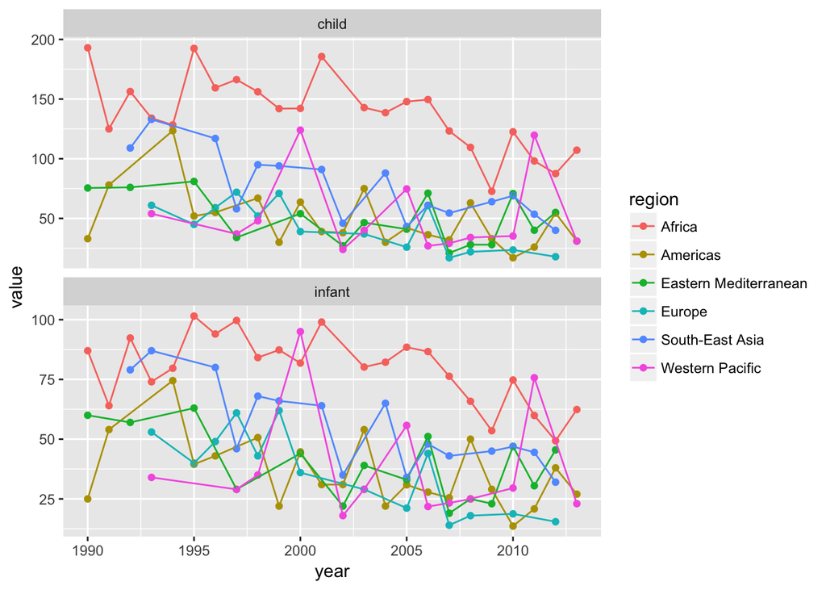

```r
mortality_yr_region_reshaped <- mortality_yr_region %>% gather(variable, value, infant, child)

library(ggplot2)
ggplot(mortality_yr_region_reshaped, aes(x=year, y=value, group=region, color=region))+geom_point()+geom_line()+facet_wrap(~variable, nrow=2,scales='free_y')
```

5. Create a panel of plots, one for each **region**, where each plot shows the average value of each indicator over time.

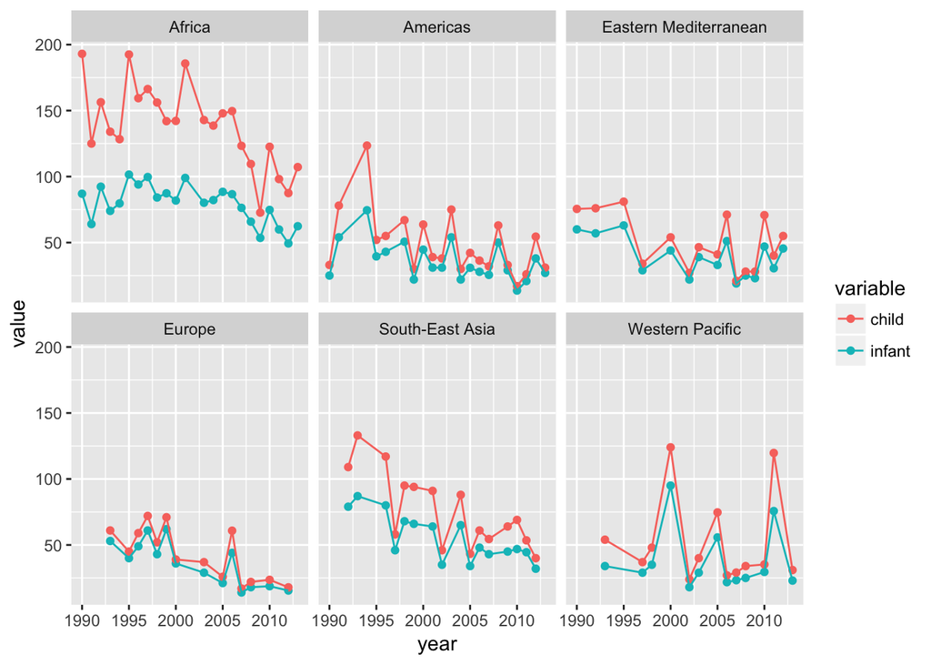

```r
ggplot(mortality_yr_region_reshaped, aes(x=year, y=value, group=variable, color=variable))+geom_point()+geom_line()+facet_wrap(~region, nrow=2)
```